# ‘A quantitative analysis using feature engineering to train and predict AI models using Machine learning’

## Section 3.2

In Section 3.2 We use summary statistics particularly mean, median, range and interquartile range. After we explore the averages,we look to explore the standard deviation. For this we split the data into two sets: “data_letters” and “data_nonletters” and examine them below using the table. We will examine the tables individually before we compare and contrast.Next We explore the standard deviation, Standard deviation is a statistic that measures the dispersion of a dataset relative to its mean,below is the fomrulatic expression.
$$\begin{equation}
s = \sqrt\frac{\sum{(x_i-\bar{x})^2}}{n-1}
\end{equation}$$
*s* = Sample S.D. $x_i$ = individual value $\bar{x}$ = Sample mean n = Sample size

If the data points are further from the mean, there is a higher deviation within the data set; thus, the more spread out the data, the higher the standard deviation. A standard deviation close to zero indicates that data points are close to the mean, whereas a high or low standard deviation indicates data points are respectively above or below the mean.

```r
kable(output_letters_3.2,capation = "Statsical analysis into letters ")
```

|  | nr_pix | row_with_1 | cols_with_1 | rows_with_3p | cols_with_3p | aspect_ratio | no_neigh_left | no_neigh_right | no_neigh_above | no_neigh_below | no_neigh_vert | no_neigh_horiz |
| --- | --- | --- | --- | --- | --- | --- | --- | --- | --- | --- | --- | --- |
| letters_min | 12.000000 | 0.000000 | 0.000000 | 0.000000 | 1.000000 | 5.000000 | 0.000000 | 1.00000 | 3.000000 | 0.1304348 | 1.000000 | 1.000000 |
| letters_q1 | 24.000000 | 1.000000 | 0.000000 | 3.000000 | 3.000000 | 9.000000 | 2.000000 | 6.75000 | 6.000000 | 0.2990741 | 4.000000 | 4.000000 |
| letters_median | 27.000000 | 3.000000 | 1.000000 | 4.000000 | 4.000000 | 11.000000 | 4.000000 | 9.00000 | 9.000000 | 0.4258242 | 6.000000 | 6.000000 |
| letters_mean | 28.837500 | 3.375000 | 1.562500 | 4.062500 | 4.225000 | 10.612500 | 4.275000 | 9.01250 | 9.025000 | 0.4630002 | 6.875000 | 6.450000 |
| letters_q3 | 33.000000 | 5.000000 | 3.000000 | 5.000000 | 5.250000 | 13.000000 | 6.000000 | 11.00000 | 11.250000 | 0.5854839 | 9.000000 | 8.000000 |
| letters_max | 56.000000 | 10.000000 | 7.000000 | 11.000000 | 11.000000 | 16.000000 | 12.000000 | 16.00000 | 17.000000 | 1.0909091 | 20.000000 | 20.000000 |
| letters_sd | 8.220757 | 2.965519 | 1.741844 | 2.235183 | 2.164004 | 2.587672 | 2.963811 | 3.35455 | 3.337455 | 0.2237195 | 3.756429 | 3.655757 |

```r
kable(output_nonletters_3.2,capation = "Statsical analysis into letters ")
```

|  | nr_pix | row_with_1 | cols_with_1 | rows_with_3p | cols_with_3p | aspect_ratio | no_neigh_left | no_neigh_right | no_neigh_above | no_neigh_below | no_neigh_vert | no_neigh_horiz |
| --- | --- | --- | --- | --- | --- | --- | --- | --- | --- | --- | --- | --- |
| nonletters_min | 27.00000 | 0.0000000 | 0.000000 | 5.000000 | 3.000000 | 8.000000 | 0.000000 | 0.000000 | 7.000000 | 0.0483871 | 2.00000 | 1.000000 |
| nonletters_q1 | 48.75000 | 0.0000000 | 0.000000 | 9.000000 | 5.000000 | 11.000000 | 6.000000 | 12.000000 | 12.000000 | 0.2302198 | 8.00000 | 8.000000 |
| nonletters_median | 61.00000 | 0.0000000 | 0.000000 | 11.000000 | 8.000000 | 13.000000 | 8.000000 | 14.000000 | 13.500000 | 0.4012195 | 11.00000 | 12.000000 |
| nonletters_mean | 61.15000 | 0.0833333 | 1.533333 | 11.116667 | 8.000000 | 12.433333 | 7.883333 | 14.300000 | 14.100000 | 0.3727182 | 10.73333 | 11.450000 |
| nonletters_q3 | 70.00000 | 0.0000000 | 2.250000 | 13.000000 | 10.000000 | 14.000000 | 10.250000 | 17.000000 | 16.250000 | 0.4647616 | 14.00000 | 15.250000 |
| nonletters_max | 98.00000 | 2.0000000 | 9.000000 | 16.000000 | 16.000000 | 17.000000 | 13.000000 | 28.000000 | 27.000000 | 0.6956522 | 19.00000 | 20.000000 |
| nonletters_sd | 15.87966 | 0.3340388 | 2.375487 | 2.718996 | 3.047644 | 1.977558 | 3.622396 | 4.187552 | 3.657822 | 0.1449272 | 4.36421 | 4.770762 |

—————Letters —————

When studying our tables I have moved from left to right as if it is normally distrubted to be able to view the boundraies. we notice trends emerging within the data set. One noticeable example is the similarity between the mean and median values which suggests our data is symmetrically distributed. It is interesting to see the difference in values <1, <2 and >2. With the majority being less than 1, these results seem like valuable features for symbol analysis as it has lower differences but overall a great distinable feature if our data was thrown into a set of new random images. We can however only choose which features are valuable in identification when we compare it against non_letter data.

For the interquartile range of an observation variable is the difference of its upper and lower quartiles. It is a measure of how far apart the middle portion of data spreads in value. Within this inter-quartile range, favourable data occurs with lower results. We can discount nr_pix because the data is dense and would produce a large inter-quartile range. What is interesting is the low inter-quartile ranges for both rows and columns that have 1 pixel. I expected it to have a larger inter quartile range. I suspect along with the range calculation of the group that this is wrong and rule them both out in this analyis.

Overall I am happy with the leading on the mean and median values with guidance from the range and inter-quartile range.

—————Non-Letters—————

—————Features —————

—————Row_with_1—————

I selcted this one due to the favaorble closeness of mean and median but more the fact it presents 0 for 4 categories comapred to only 1 in letters.

—————Rows_with_3p—————

Noticably in my standard devaition particylar low results were any row analysis I pair this with also the consistent data presneted from the summery statstics

—————no_neigh_vert —————

This feature discrimates letters from non-letters as all non-letters have an overhaed pixel this is suported by the summery statistics and nice whole numbers

####Section 3.2 graphs

—————Legend ————— Pink line = Letters Green line = non letters black = entrie set

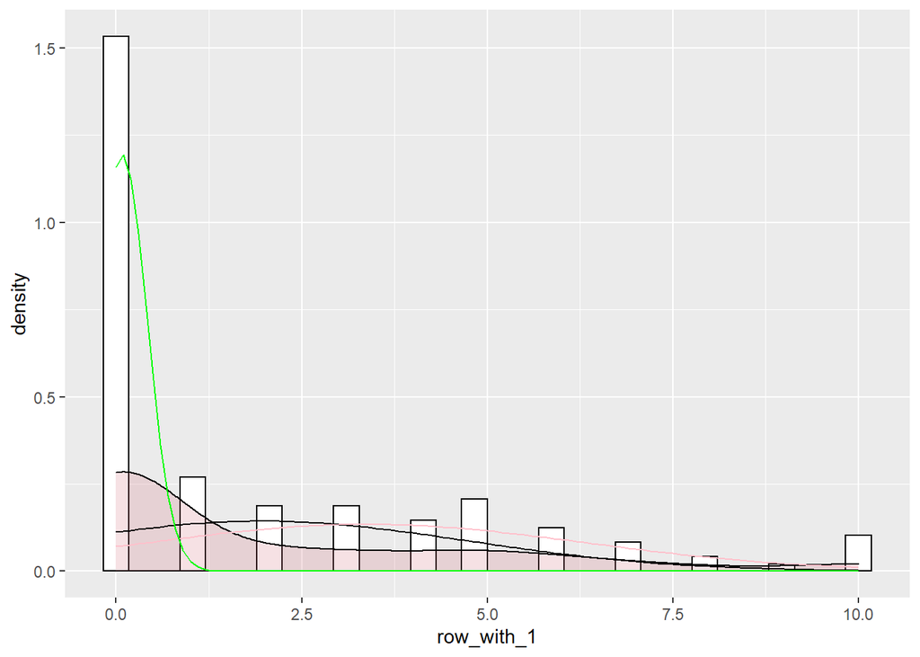

```r
f1
```

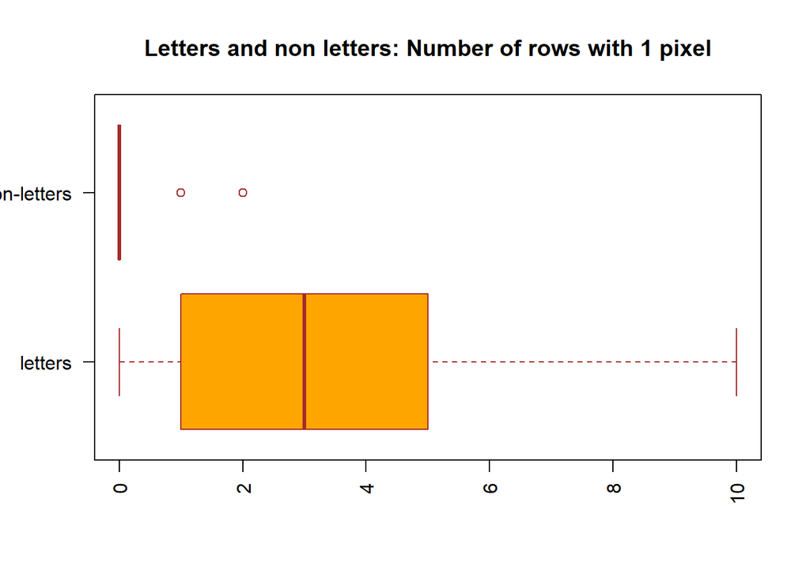

```r
 boxplot(letters_row_with1, nonletters_row_with1,
        main = "Letters and non letters: Number of rows with 1 pixel",
        at = c(1,2),
        names = c("letters", "non-letters"),
        las = 2,
        col = c("orange","lightblue"),
        border = "brown",
        horizontal = TRUE,
        notch = FALSE)
```

fig(7) As seen above there appears to be a higher density of non_letters,then it drops off and is not present,We see a small slight rise in letters.This could be useful when we distinauble the boundary and use it for classfication.The box plot shows us that non letters is very contained and letters has most of its data not over lapping.This has been a successfull choice

```r
geom_histogram(color="black", fill="white",binwidth = 2)
```

```
## geom_bar: na.rm = FALSE, orientation = NA
## stat_bin: binwidth = 2, bins = NULL, na.rm = FALSE, orientation = NA, pad = FALSE
## position_stack
```

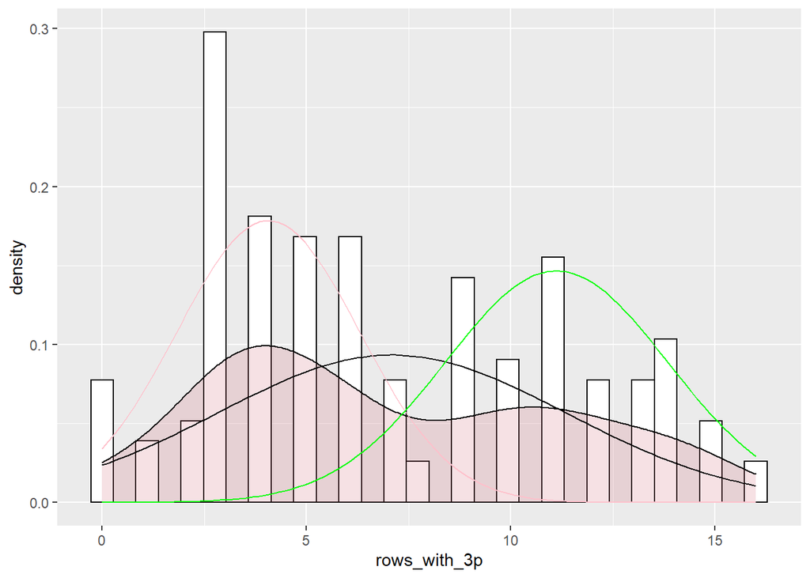

```r
 f2<-ggplot(dataFeature, aes(x=rows_with_3p)) +
 geom_histogram(aes(y=..density..), colour="black",fill="white")+
 geom_density(alpha=.2, fill="#D16A76")  +
  stat_function(fun = dnorm, args = list(mean = mean(data$rows_with_3p), sd = sd(data$rows_with_3p)))+
   stat_function(fun = dnorm, args = list(mean = mean(data_letters$rows_with_3p), sd = sd(data_letters$rows_with_3p)),colour = "pink")+
   stat_function(fun = dnorm, args = list(mean = mean(data_nonletters$rows_with_3p), sd = sd(data_nonletters$rows_with_3p)),colour = "green")



f2
```

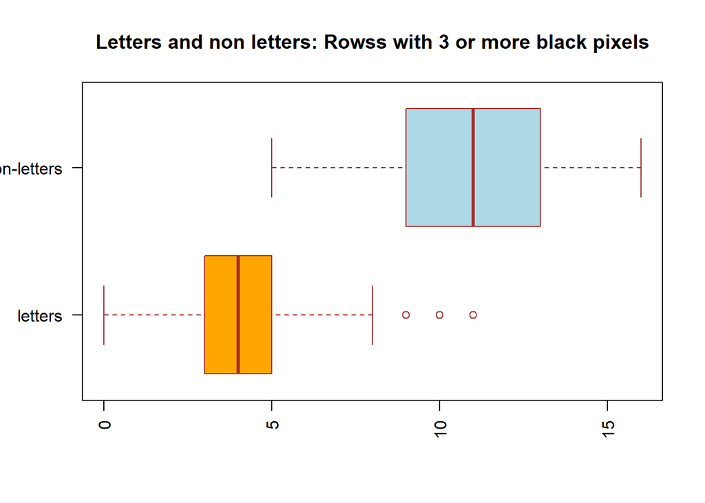

```r
# prepare the data
letters_rows_with_3p <- data_letters$rows_with_3p
nonletters_rows_with_3p <- data_nonletters$rows_with_3p

# box plot to compare the number of diagonals data
boxplot(letters_rows_with_3p, nonletters_rows_with_3p,
        main = "Letters and non letters: Rowss with 3 or more black pixels",
        at = c(1,2),
        names = c("letters", "non-letters"),
        las = 2,
        col = c("orange","lightblue"),
        border = "brown",
        horizontal = TRUE,
        notch = FALSE
)
```

```r
geom_histogram(color="black", fill="white",binwidth = 2)
```

```
## geom_bar: na.rm = FALSE, orientation = NA
## stat_bin: binwidth = 2, bins = NULL, na.rm = FALSE, orientation = NA, pad = FALSE
## position_stack
```

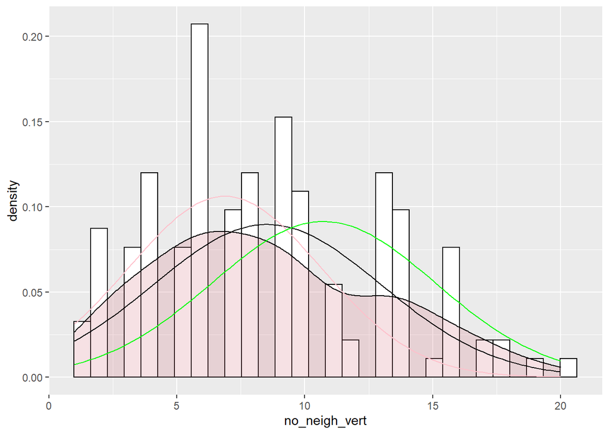

```r
 f3<-ggplot(dataFeature, aes(x=no_neigh_vert)) +
 geom_histogram(aes(y=..density..), colour="black",fill="white")+
 geom_density(alpha=.2, fill="#D16A76")  +
  stat_function(fun = dnorm, args = list(mean = mean(data$no_neigh_vert), sd = sd(data$no_neigh_vert)))+
   stat_function(fun = dnorm, args = list(mean = mean(data_letters$no_neigh_vert), sd = sd(data_letters$no_neigh_vert)),colour = "pink")+
   stat_function(fun = dnorm, args = list(mean = mean(data_nonletters$no_neigh_vert), sd = sd(data_nonletters$no_neigh_vert)),colour = "green")



f3
```

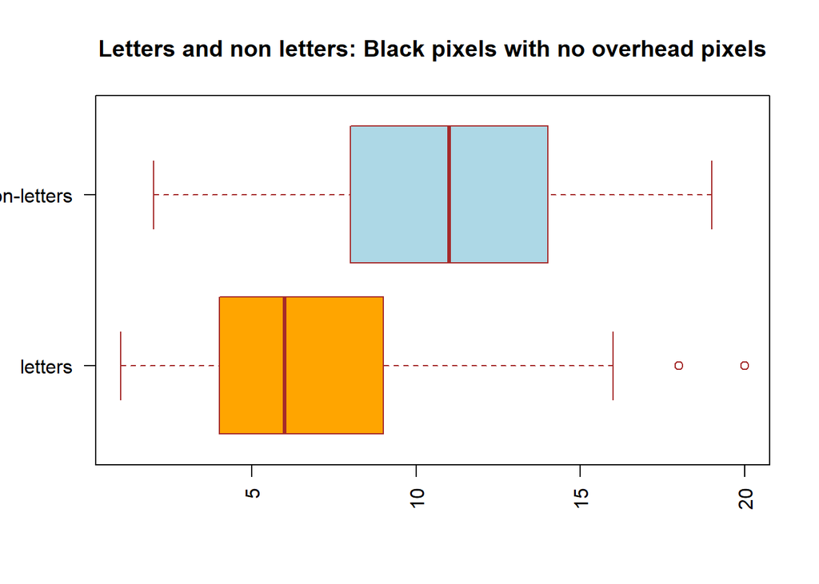

```r
# prepare the data
letters_no_neigh_vert<- data_letters$no_neigh_vert
nonletters_no_neigh_vert <- data_nonletters$no_neigh_vert

# box plot to compare the number of diagonals data
boxplot(letters_no_neigh_vert, nonletters_no_neigh_vert,
        main = "Letters and non letters: Black pixels with no overhead pixels",
        at = c(1,2),
        names = c("letters", "non-letters"),
        las = 2,
        col = c("orange","lightblue"),
        border = "brown",
        horizontal = TRUE,
        notch = FALSE
)
```

Fig(9) When examinging the no_neigh_vert histogram is produces no useable analysis both data sets are close to each other and the mean.The only use of this feature is if another data set complety differnet is thrown in,then used to spearate the two.In the boxplot there is an overlap of the data spread and the end of letters seems to be too close to the mean of non_letters meaning 1/2 of the data is mixed in.

#### Section 3.3

————— Introduction—————

The p-values given by the t-tests will determine whether there is a difference in the true population means between letters and non-letters of each feature. This will help us determine whether a feature will be useful to distinguish between a letter and a non-letter. Using this T statistic we can then workout the P value using the formula below .

$$\begin{equation}
t = \frac{m-\mu}{s/ \sqrt n}
\end{equation}$$
t = T-test $m$ = mean $\mu$ = theorical value s = Standard deviation n = varaible set size

For these t-tests We assume the conditions for inference are met, meaning a random sample and varaibles are independent.

————— Hypothesis testing —————

Our null hypothesis will be that for each feature, there will be no difference in their population means.

```r
kable(output_t,capation = "Statsical analysis using t-tests")
```

| feature_name | pval | pval1 |
| --- | --- | --- |
| nr_pix | 2.44293554456541e-32 | -72.7895225676046 |
| row_with_1 | 2.08078410942649e-14 | -31.5034465035551 |
| cols_with_1 | 0.933305433546108 | -0.0690227645629155 |
| rows_with_3p | 2.92353913244709e-35 | -79.5176833407689 |
| cols_with_3p | 1.84981110014758e-14 | -31.6211077760681 |
| aspect_ratio | 1.19379594297862e-05 | -11.3357873666332 |
| no_neigh_left | 1.52107847566848e-09 | -20.3038462302149 |
| no_neigh_right | 8.86488680431937e-14 | -30.0540931313023 |
| no_neigh_above | 2.1494243577241e-14 | -31.4709912362194 |
| no_neigh_below | 0.00726155393223076 | -4.92516143279661 |
| no_neigh_vert | 1.06943277839776e-07 | -16.0509672566914 |
| no_neigh_horiz | 9.05989230182333e-11 | -23.1245787901662 |
| eyes | 1.47593288994688e-06 | -13.4262203003353 |

————— P values —————

##Section 3.4

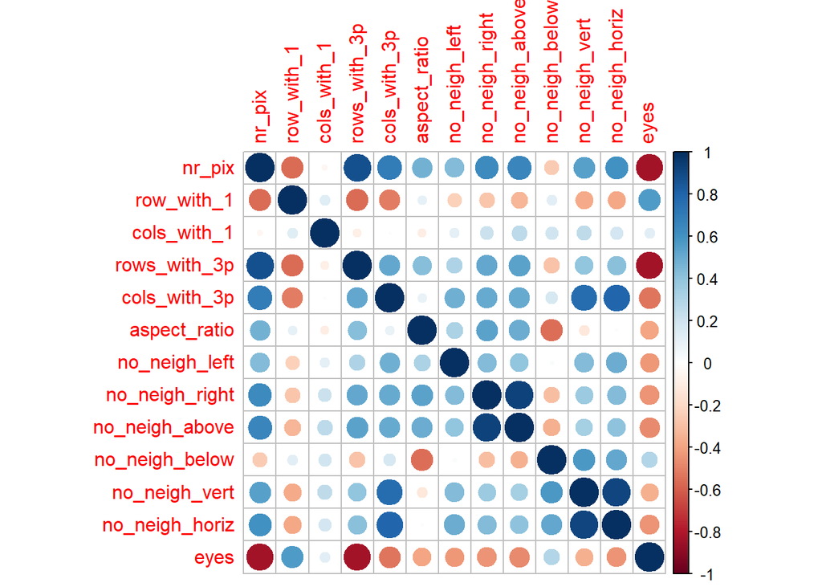

```r
# Correlation plot with circles:
library(corrplot)
# correlation plot with circles
correlations <- cor(data[,3:15])
corrplot(correlations, method="circle")
```

```r
corr = round(cor(data[,3:15]),1)
kable(corr,capation = "Correlation analysis ")
```

|  | nr_pix | row_with_1 | cols_with_1 | rows_with_3p | cols_with_3p | aspect_ratio | no_neigh_left | no_neigh_right | no_neigh_above | no_neigh_below | no_neigh_vert | no_neigh_horiz | eyes |
| --- | --- | --- | --- | --- | --- | --- | --- | --- | --- | --- | --- | --- | --- |
| nr_pix | 1.0 | -0.6 | 0.0 | 0.9 | 0.7 | 0.5 | 0.4 | 0.6 | 0.7 | -0.3 | 0.5 | 0.6 | -0.8 |
| row_with_1 | -0.6 | 1.0 | 0.1 | -0.6 | -0.5 | 0.1 | -0.2 | -0.3 | -0.3 | 0.1 | -0.4 | -0.4 | 0.6 |
| cols_with_1 | 0.0 | 0.1 | 1.0 | -0.1 | 0.0 | -0.1 | 0.1 | 0.2 | 0.3 | 0.2 | 0.3 | 0.2 | 0.1 |
| rows_with_3p | 0.9 | -0.6 | -0.1 | 1.0 | 0.5 | 0.4 | 0.3 | 0.5 | 0.5 | -0.3 | 0.4 | 0.4 | -0.8 |
| cols_with_3p | 0.7 | -0.5 | 0.0 | 0.5 | 1.0 | 0.1 | 0.5 | 0.5 | 0.5 | 0.2 | 0.8 | 0.8 | -0.5 |
| aspect_ratio | 0.5 | 0.1 | -0.1 | 0.4 | 0.1 | 1.0 | 0.3 | 0.5 | 0.5 | -0.6 | -0.1 | 0.0 | -0.4 |
| no_neigh_left | 0.4 | -0.2 | 0.1 | 0.3 | 0.5 | 0.3 | 1.0 | 0.4 | 0.4 | 0.0 | 0.4 | 0.5 | -0.4 |
| no_neigh_right | 0.6 | -0.3 | 0.2 | 0.5 | 0.5 | 0.5 | 0.4 | 1.0 | 0.9 | -0.3 | 0.4 | 0.4 | -0.4 |
| no_neigh_above | 0.7 | -0.3 | 0.3 | 0.5 | 0.5 | 0.5 | 0.4 | 0.9 | 1.0 | -0.4 | 0.3 | 0.4 | -0.5 |
| no_neigh_below | -0.3 | 0.1 | 0.2 | -0.3 | 0.2 | -0.6 | 0.0 | -0.3 | -0.4 | 1.0 | 0.6 | 0.5 | 0.3 |
| no_neigh_vert | 0.5 | -0.4 | 0.3 | 0.4 | 0.8 | -0.1 | 0.4 | 0.4 | 0.3 | 0.6 | 1.0 | 0.9 | -0.4 |
| no_neigh_horiz | 0.6 | -0.4 | 0.2 | 0.4 | 0.8 | 0.0 | 0.5 | 0.4 | 0.4 | 0.5 | 0.9 | 1.0 | -0.4 |
| eyes | -0.8 | 0.6 | 0.1 | -0.8 | -0.5 | -0.4 | -0.4 | -0.4 | -0.5 | 0.3 | -0.4 | -0.4 | 1.0 |